# Chapter 9

```r
library("tidyverse")
library("lubridate")
```

The principle behind tidy data is simple: storing your data in a consistent way makes it easier to work with it.

Tidy data is a mapping between the statistical structure of a data frame (variables and observations) and the physical structure (columns and rows).

Tidy data follows two main principles: 1. Variables go in columns. 2. Observations go in rows.

Either form could be tidy depending on what the values “A”, “B”, “C”, “D” mean.

[NOTE] Interesting point about missing values, explicit in one, implicit in the other

```r
indexed <- data.frame(
  x = c("a", "b", "c", "d", "c"),
  y = c("A", "D", "A", "C", "B"),
  z = c(1, 5, 4, 9, 10)
) %>% arrange(x, y)
matrix <- indexed %>% spread(y, z)

indexed
matrix
```

[output not shown]

### Gathering

Translating Cartesian to Indexed

### Spreading

Translating Indexed data to Cartesian

# Tidyr

gather() and spread() functions

```r
ec2
```

|  | month | 2006 | 2007 | 2008 | 2009 | 2010 | 2011 | 2012 | 2013 | 2014 | 2015 |
| --- | --- | --- | --- | --- | --- | --- | --- | --- | --- | --- | --- |
| 1 | 1 | 8.6 | 8.3 | 9.0 | 10.7 | 20.0 | 21.6 | 21.0 | 16.2 | 15.9 | 13.4 |
| 2 | 2 | 9.1 | 8.5 | 8.7 | 11.7 | 19.9 | 21.1 | 19.8 | 17.5 | 16.2 | 13.1 |
| 3 | 3 | 8.7 | 9.1 | 8.7 | 12.3 | 20.4 | 21.5 | 19.2 | 17.7 | 15.9 | 12.2 |
| 4 | 4 | 8.4 | 8.6 | 9.4 | 13.1 | 22.1 | 20.9 | 19.1 | 17.1 | 15.6 | 11.7 |
| 5 | 5 | 8.5 | 8.2 | 7.9 | 14.2 | 22.3 | 21.6 | 19.9 | 17.0 | 14.5 | NA |
| 6 | 6 | 7.3 | 7.7 | 9.0 | 17.2 | 25.2 | 22.3 | 20.1 | 16.6 | 13.2 | NA |
| 7 | 7 | 8.0 | 8.7 | 9.7 | 16.0 | 22.3 | 22.0 | 17.5 | 16.3 | 13.5 | NA |
| 8 | 8 | 8.4 | 8.8 | 9.7 | 16.3 | 21.0 | 22.4 | 18.5 | 16.8 | 13.3 | NA |
| 9 | 9 | 8.0 | 8.7 | 10.2 | 17.8 | 20.3 | 22.0 | 18.8 | 16.5 | 13.3 | NA |
| 10 | 10 | 7.9 | 8.4 | 10.4 | 18.9 | 21.2 | 20.5 | 19.7 | 16.1 | 13.5 | NA |

[output cut: 2 more lines]

```r
gather(ec2, key = year, value = unemp, `2006`:`2015`)
```

| month | year | unemp |
| --- | --- | --- |
| 1 | 2006 | 8.6 |
| 2 | 2006 | 9.1 |
| 3 | 2006 | 8.7 |
| 4 | 2006 | 8.4 |
| 5 | 2006 | 8.5 |
| 6 | 2006 | 7.3 |
| 7 | 2006 | 8.0 |
| 8 | 2006 | 8.4 |
| 9 | 2006 | 8.0 |
| 10 | 2006 | 7.9 |

[output cut: 110 more lines]

```r
gather(ec2, key = year, value = unemp, -month)
```

| month | year | unemp |
| --- | --- | --- |
| 1 | 2006 | 8.6 |
| 2 | 2006 | 9.1 |
| 3 | 2006 | 8.7 |
| 4 | 2006 | 8.4 |
| 5 | 2006 | 8.5 |
| 6 | 2006 | 7.3 |
| 7 | 2006 | 8.0 |
| 8 | 2006 | 8.4 |
| 9 | 2006 | 8.0 |
| 10 | 2006 | 7.9 |

[output cut: 110 more lines]

```r
ec2
```

|  | month | 2006 | 2007 | 2008 | 2009 | 2010 | 2011 | 2012 | 2013 | 2014 | 2015 |
| --- | --- | --- | --- | --- | --- | --- | --- | --- | --- | --- | --- |
| 1 | 1 | 8.6 | 8.3 | 9.0 | 10.7 | 20.0 | 21.6 | 21.0 | 16.2 | 15.9 | 13.4 |
| 2 | 2 | 9.1 | 8.5 | 8.7 | 11.7 | 19.9 | 21.1 | 19.8 | 17.5 | 16.2 | 13.1 |
| 3 | 3 | 8.7 | 9.1 | 8.7 | 12.3 | 20.4 | 21.5 | 19.2 | 17.7 | 15.9 | 12.2 |
| 4 | 4 | 8.4 | 8.6 | 9.4 | 13.1 | 22.1 | 20.9 | 19.1 | 17.1 | 15.6 | 11.7 |
| 5 | 5 | 8.5 | 8.2 | 7.9 | 14.2 | 22.3 | 21.6 | 19.9 | 17.0 | 14.5 | NA |
| 6 | 6 | 7.3 | 7.7 | 9.0 | 17.2 | 25.2 | 22.3 | 20.1 | 16.6 | 13.2 | NA |
| 7 | 7 | 8.0 | 8.7 | 9.7 | 16.0 | 22.3 | 22.0 | 17.5 | 16.3 | 13.5 | NA |
| 8 | 8 | 8.4 | 8.8 | 9.7 | 16.3 | 21.0 | 22.4 | 18.5 | 16.8 | 13.3 | NA |
| 9 | 9 | 8.0 | 8.7 | 10.2 | 17.8 | 20.3 | 22.0 | 18.8 | 16.5 | 13.3 | NA |
| 10 | 10 | 7.9 | 8.4 | 10.4 | 18.9 | 21.2 | 20.5 | 19.7 | 16.1 | 13.5 | NA |

[output cut: 2 more lines]

```r
gather(ec2, year, rate, `2006`:`2015`, na.rm = TRUE)
```

|  | month | year | rate |
| --- | --- | --- | --- |
| 1 | 1 | 2006 | 8.6 |
| 2 | 2 | 2006 | 9.1 |
| 3 | 3 | 2006 | 8.7 |
| 4 | 4 | 2006 | 8.4 |
| 5 | 5 | 2006 | 8.5 |
| 6 | 6 | 2006 | 7.3 |
| 7 | 7 | 2006 | 8.0 |
| 8 | 8 | 2006 | 8.4 |
| 9 | 9 | 2006 | 8.0 |
| 10 | 10 | 2006 | 7.9 |

[output cut: 102 more lines]

```r
gather(ec2, year, rate, `2006`:`2015`, convert = TRUE)
```

| month | year | rate |
| --- | --- | --- |
| 1 | 2006 | 8.6 |
| 2 | 2006 | 9.1 |
| 3 | 2006 | 8.7 |
| 4 | 2006 | 8.4 |
| 5 | 2006 | 8.5 |
| 6 | 2006 | 7.3 |
| 7 | 2006 | 8.0 |
| 8 | 2006 | 8.4 |
| 9 | 2006 | 8.0 |
| 10 | 2006 | 7.9 |

[output cut: 110 more lines]

```r
# convert = TRUE automatically converts years from character strings to numbers
gather(ec2, year, rate, `2006`:`2015`, convert = TRUE, na.rm = TRUE)
```

|  | month | year | rate |
| --- | --- | --- | --- |
| 1 | 1 | 2006 | 8.6 |
| 2 | 2 | 2006 | 9.1 |
| 3 | 3 | 2006 | 8.7 |
| 4 | 4 | 2006 | 8.4 |
| 5 | 5 | 2006 | 8.5 |
| 6 | 6 | 2006 | 7.3 |
| 7 | 7 | 2006 | 8.0 |
| 8 | 8 | 2006 | 8.4 |
| 9 | 9 | 2006 | 8.0 |
| 10 | 10 | 2006 | 7.9 |

[output cut: 102 more lines]

```r
ec2
```

|  | month | 2006 | 2007 | 2008 | 2009 | 2010 | 2011 | 2012 | 2013 | 2014 | 2015 |
| --- | --- | --- | --- | --- | --- | --- | --- | --- | --- | --- | --- |
| 1 | 1 | 8.6 | 8.3 | 9.0 | 10.7 | 20.0 | 21.6 | 21.0 | 16.2 | 15.9 | 13.4 |
| 2 | 2 | 9.1 | 8.5 | 8.7 | 11.7 | 19.9 | 21.1 | 19.8 | 17.5 | 16.2 | 13.1 |
| 3 | 3 | 8.7 | 9.1 | 8.7 | 12.3 | 20.4 | 21.5 | 19.2 | 17.7 | 15.9 | 12.2 |
| 4 | 4 | 8.4 | 8.6 | 9.4 | 13.1 | 22.1 | 20.9 | 19.1 | 17.1 | 15.6 | 11.7 |
| 5 | 5 | 8.5 | 8.2 | 7.9 | 14.2 | 22.3 | 21.6 | 19.9 | 17.0 | 14.5 | NA |
| 6 | 6 | 7.3 | 7.7 | 9.0 | 17.2 | 25.2 | 22.3 | 20.1 | 16.6 | 13.2 | NA |
| 7 | 7 | 8.0 | 8.7 | 9.7 | 16.0 | 22.3 | 22.0 | 17.5 | 16.3 | 13.5 | NA |
| 8 | 8 | 8.4 | 8.8 | 9.7 | 16.3 | 21.0 | 22.4 | 18.5 | 16.8 | 13.3 | NA |
| 9 | 9 | 8.0 | 8.7 | 10.2 | 17.8 | 20.3 | 22.0 | 18.8 | 16.5 | 13.3 | NA |
| 10 | 10 | 7.9 | 8.4 | 10.4 | 18.9 | 21.2 | 20.5 | 19.7 | 16.1 | 13.5 | NA |

[output cut: 2 more lines]

```r
economics_2 <- gather(ec2, year, rate, `2006`:`2015`, convert = TRUE, na.rm = TRUE)
economics_2
```

|  | month | year | rate |
| --- | --- | --- | --- |
| 1 | 1 | 2006 | 8.6 |
| 2 | 2 | 2006 | 9.1 |
| 3 | 3 | 2006 | 8.7 |
| 4 | 4 | 2006 | 8.4 |
| 5 | 5 | 2006 | 8.5 |
| 6 | 6 | 2006 | 7.3 |
| 7 | 7 | 2006 | 8.0 |
| 8 | 8 | 2006 | 8.4 |
| 9 | 9 | 2006 | 8.0 |
| 10 | 10 | 2006 | 7.9 |

[output cut: 102 more lines]

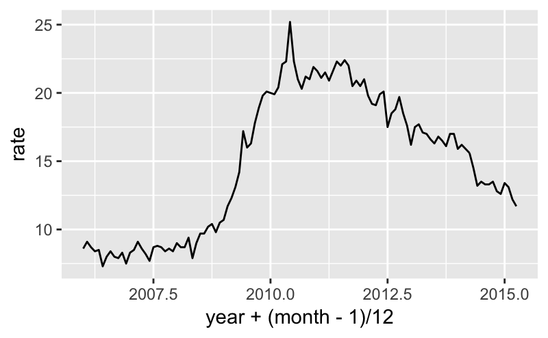

```r
ggplot(economics_2, aes(year + (month - 1) / 12, rate)) + geom_line()
```

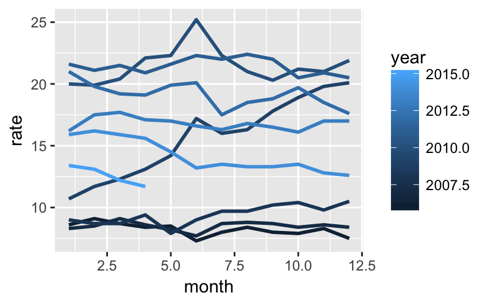

```r
# Group by Year
ggplot(economics_2, aes(month, rate, group = year)) + geom_line(aes(colour = year), size = 1)
```

# Spread

```r
weather <- dplyr::data_frame(
  day = rep(1:3, 2),
  obs = rep(c("temp", "rain"), each = 3),
  val = c(c(23, 22, 20), c(0, 0, 5))
)
weather
```

| day | obs | val |
| --- | --- | --- |
| 1 | temp | 23 |
| 2 | temp | 22 |
| 3 | temp | 20 |
| 1 | rain | 0 |
| 2 | rain | 0 |
| 3 | rain | 5 |

```r
spread(weather, key = obs, value = val)
```

|  | day | rain | temp |
| --- | --- | --- | --- |
| 1 | 1 | 0 | 23 |
| 2 | 2 | 0 | 22 |
| 3 | 3 | 5 | 20 |

# Exercises

### How can you translate each of the initial example datasets into the other form?

```r
economics <- ggplot2::economics
economics
```

| date | pce | pop | psavert | uempmed | unemploy |
| --- | --- | --- | --- | --- | --- |
| 1967-07-01 | 507.4 | 198712 | 12.5 | 4.5 | 2944 |
| 1967-08-01 | 510.5 | 198911 | 12.5 | 4.7 | 2945 |
| 1967-09-01 | 516.3 | 199113 | 11.7 | 4.6 | 2958 |
| 1967-10-01 | 512.9 | 199311 | 12.5 | 4.9 | 3143 |
| 1967-11-01 | 518.1 | 199498 | 12.5 | 4.7 | 3066 |
| 1967-12-01 | 525.8 | 199657 | 12.1 | 4.8 | 3018 |
| 1968-01-01 | 531.5 | 199808 | 11.7 | 5.1 | 2878 |
| 1968-02-01 | 534.2 | 199920 | 12.2 | 4.5 | 3001 |
| 1968-03-01 | 544.9 | 200056 | 11.6 | 4.1 | 2877 |
| 1968-04-01 | 544.6 | 200208 | 12.2 | 4.6 | 2709 |

[output cut: 564 more lines]

```r
gather(economics, key="metric", value="value", -date)
```

| date | metric | value |
| --- | --- | --- |
| 1967-07-01 | pce | 507.4 |
| 1967-08-01 | pce | 510.5 |
| 1967-09-01 | pce | 516.3 |
| 1967-10-01 | pce | 512.9 |
| 1967-11-01 | pce | 518.1 |
| 1967-12-01 | pce | 525.8 |
| 1968-01-01 | pce | 531.5 |
| 1968-02-01 | pce | 534.2 |
| 1968-03-01 | pce | 544.9 |
| 1968-04-01 | pce | 544.6 |

[output cut: 990 more lines]

### How can you convert back and forth between the economics and economics_long datasets built into ggplot2?

```r
summary(economics)
```

```
      date                 pce               pop            psavert          uempmed         unemploy
 Min.   :1967-07-01   Min.   :  507.4   Min.   :198712   Min.   : 1.900   Min.   : 4.00   Min.   : 2685
 1st Qu.:1979-06-08   1st Qu.: 1582.2   1st Qu.:224896   1st Qu.: 5.500   1st Qu.: 6.00   1st Qu.: 6284
 Median :1991-05-16   Median : 3953.6   Median :253060   Median : 7.700   Median : 7.50   Median : 7494
 Mean   :1991-05-17   Mean   : 4843.5   Mean   :257189   Mean   : 7.937   Mean   : 8.61   Mean   : 7772
 3rd Qu.:2003-04-23   3rd Qu.: 7667.3   3rd Qu.:290291   3rd Qu.:10.500   3rd Qu.: 9.10   3rd Qu.: 8691
 Max.   :2015-04-01   Max.   :12161.5   Max.   :320887   Max.   :17.000   Max.   :25.20   Max.   :15352
```

```r
summary(economics_long)
```

```
      date                variable       value             value01
 Min.   :1967-07-01   pce     :574   Min.   :     1.9   Min.   :0.0000
 1st Qu.:1979-06-01   pop     :574   1st Qu.:     8.5   1st Qu.:0.1617
 Median :1991-05-16   psavert :574   Median :  3438.7   Median :0.3175
 Mean   :1991-05-17   uempmed :574   Mean   : 53964.2   Mean   :0.3739
 3rd Qu.:2003-05-01   unemploy:574   3rd Qu.: 10147.1   3rd Qu.:0.5585
 Max.   :2015-04-01                  Max.   :320887.0   Max.   :1.0000
```

# Seperate and Unite

| var | val |
| --- | --- |
| beg_a | 1 |
| beg_b | 4 |
| beg_c | 2 |
| end_a | 10 |
| end_b | 5 |
| end_c | 11 |

# Exercises 2

Install the EDAWR package from https://github.com/rstudio/EDAWR. Tidy the who dataset.

Work through the demos included in the tidyr package (demo(package = “tidyr”))

# Blood Pressure Case Study

```r
bpd <- readr::read_table(
"name age      start  week1  week2  week3
Anne  35 2014-03-27 100/80 100/75 120/90
 Ben  41 2014-03-09 110/65 100/65 135/70
Carl  33 2014-04-02 125/80   <NA>   <NA>
", na = "<NA>")
```

```r
bpd
```

| name | age | start | week1 | week2 | week3 |
| --- | --- | --- | --- | --- | --- |
| Anne | 35 | 2014-03-27 | 100/80 | 100/75 | 120/90 |
| Ben | 41 | 2014-03-09 | 110/65 | 100/65 | 135/70 |
| Carl | 33 | 2014-04-02 | 125/80 | NA | NA |

```r
bpd_1 <- gather(bpd, week, bp, week1:week3)
bpd_1
```

| name | age | start | week | bp |
| --- | --- | --- | --- | --- |
| Anne | 35 | 2014-03-27 | week1 | 100/80 |
| Ben | 41 | 2014-03-09 | week1 | 110/65 |
| Carl | 33 | 2014-04-02 | week1 | 125/80 |
| Anne | 35 | 2014-03-27 | week2 | 100/75 |
| Ben | 41 | 2014-03-09 | week2 | 100/65 |
| Carl | 33 | 2014-04-02 | week2 | NA |
| Anne | 35 | 2014-03-27 | week3 | 120/90 |
| Ben | 41 | 2014-03-09 | week3 | 135/70 |
| Carl | 33 | 2014-04-02 | week3 | NA |

Seperate the bp variable

```r
bpd_2 <- separate(bpd_1, bp, c("sys", "dia"), "/")
```

[output not shown]

Pull out week number

| name | age | start | week | sys | dia |
| --- | --- | --- | --- | --- | --- |
| Anne | 35 | 2014-03-27 | 1 | 100 | 80 |
| Anne | 35 | 2014-03-27 | 2 | 100 | 75 |
| Anne | 35 | 2014-03-27 | 3 | 120 | 90 |
| Ben | 41 | 2014-03-09 | 1 | 110 | 65 |
| Ben | 41 | 2014-03-09 | 2 | 100 | 65 |
| Ben | 41 | 2014-03-09 | 3 | 135 | 70 |
| Carl | 33 | 2014-04-02 | 1 | 125 | 80 |
| Carl | 33 | 2014-04-02 | 2 | NA | NA |
| Carl | 33 | 2014-04-02 | 3 | NA | NA |

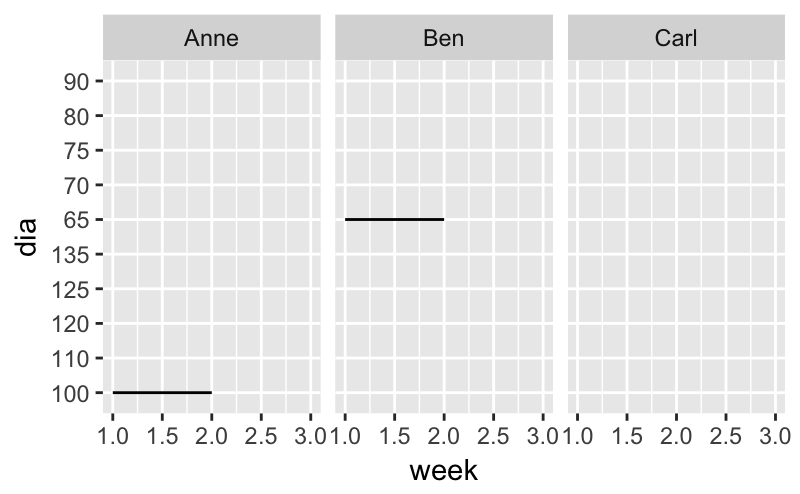

```r
ggplot(bpd_4, aes(x = week)) + geom_line(aes(y=dia)) + geom_line(aes(y=sys)) + facet_wrap(~ name)
```

# Test Scores Case Study

```r
scores <- dplyr::data_frame(
  person = rep(c("Greg", "Sally", "Sue"), each = 2),
  time   = rep(c("pre", "post"), 3),
  test1  = round(rnorm(6, mean = 80, sd = 4), 0),
  test2  = round(jitter(test1, 15), 0)
)
scores
```

| person | time | test1 | test2 |
| --- | --- | --- | --- |
| Greg | pre | 76 | 79 |
| Greg | post | 79 | 76 |
| Sally | pre | 81 | 82 |
| Sally | post | 80 | 79 |
| Sue | pre | 77 | 75 |
| Sue | post | 83 | 82 |

```r
scores_1 <- gather(scores, test, score, test1:test2)
scores_1
```

| person | time | test | score |
| --- | --- | --- | --- |
| Greg | pre | test1 | 76 |
| Greg | post | test1 | 79 |
| Sally | pre | test1 | 81 |
| Sally | post | test1 | 80 |
| Sue | pre | test1 | 77 |
| Sue | post | test1 | 83 |
| Greg | pre | test2 | 79 |
| Greg | post | test2 | 76 |
| Sally | pre | test2 | 82 |
| Sally | post | test2 | 79 |

[output cut: 2 more lines]

```r
scores_2 <- spread(scores_1, time, score)
scores_2
```

|  | person | test | post | pre |
| --- | --- | --- | --- | --- |
| 1 | Greg | test1 | 79 | 76 |
| 2 | Greg | test2 | 76 | 79 |
| 3 | Sally | test1 | 80 | 81 |
| 4 | Sally | test2 | 79 | 82 |
| 5 | Sue | test1 | 83 | 77 |
| 6 | Sue | test2 | 82 | 75 |

```r
scores_3 <- mutate(scores_2, diff = post - pre)
scores_3
```

| person | test | post | pre | diff |
| --- | --- | --- | --- | --- |
| Greg | test1 | 79 | 76 | 3 |
| Greg | test2 | 76 | 79 | -3 |
| Sally | test1 | 80 | 81 | -1 |
| Sally | test2 | 79 | 82 | -3 |
| Sue | test1 | 83 | 77 | 6 |
| Sue | test2 | 82 | 75 | 7 |

Plot it

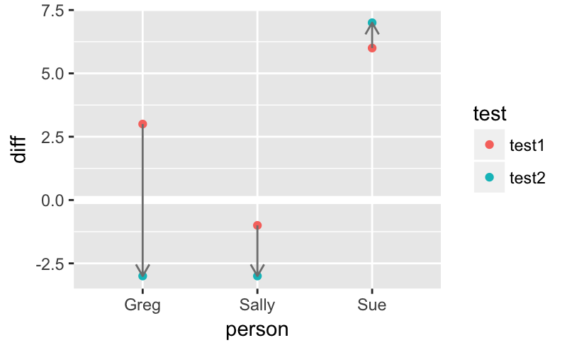

```r
ggplot(scores_3, aes(person, diff, color = test)) +
  geom_hline(size = 2, colour = "white", yintercept = 0) +
  geom_point() +
  geom_path(aes(group = person), colour = "grey50",  arrow = arrow(length = unit(0.25, "cm")))
```